# Project1

2024-03-08

### Group Members: Aleiza Belista, Hannah Sepnio

# Analyzing Austin MetroBike Trends Preceding and Following the COVID-19 Pandemic

## 1. Introduction

The dataset we have chosen to analyze is the Austin MetroBike Trips dataset from the City of Austin Data Portal. This dataset contains information on the MetroBike trips taken from 2013 to 2024. Including their check in/out date, times, and location. We are interested in this data because during our time attending UT, MetroBikes have been a primary source of transportation for students. Here we are analyzing the data set containing information on the Austin MetroBike bicycle sharing program. This data set is updated frequently. To explore this data, we wanted to find out more about MetroBike kiosk location and effects of the COVID-19 pandemic. We begin doing this by analyzing the variables: membership/pass type, kiosk location, time, month, and year.

An article written by Austin Monitor, a local news organization, discusses the $11.3 million federal grant that the Austin MetroBike program received from the Texas Department of Transportation. The grant was given to the MetroBike program to expand and enhance their services in the city of Austin. We found this topic important to investigate because we wanted to explore the relation of MetroBike trips to the probable usage of UT students for frequent transportation. We also wanted to determine if the program’s financial resources are being allocated towards demographics who are prevalent users of the Austin MetroBike program.

The main variables of interest in the dataset include the membership or pass type, checkout time, checkout kiosk, return kiosk, month, year. The numeric variables we will be investigating are checkout time, month, and year. The categorical variables will be membership or pass type, checkout kiosk, and return kiosk. A unique row of the dataset represents an individual MetroBike trip, each with a unique trip ID. We filtered queried the original data set with the following filters: year between 2019-2021, membership/pass type does not include RESTRICTED or LocalYouth365 passes, trip duration between 10-25 minutes, and Bike Type is classic only.

Prior to conducting our analysis, we expected to see an increase in MetroBike rides around the academic school year when UT students are present (during the Fall and Spring) and a decrease when there are breaks (Winter and Summer). We also expected to see a decrease in bike trips around 2020, as the COVID-19 pandemic occurred during that year. We are also expecting to see more frequent bike rides during the day time as students are travelling to and from classes. As for kiosk location, we anticipated that bikes would be frequently checked in and out in areas near UT campus or west campus where many UT students live. The first research questions that our explanatory data analysis will answer is whether or not there is an abundance of bikes in certain locations that they are being checked out or dropped off at. The second research question that we plan to answer with our analysis is how Austin MetroBikes was affected by the COVID-19 pandemic and whether or not they showed recovery from 2020. Our third research question is to analyze if students use MetroBikes frequently and what time of the day they are checking out their bikes.

## 2. Methods

First, lets import the main data set we will be using. We called it `amb` short for Austin MetroBikes.

```r
# Import Austin Metro Bike file and rename it
amb <- read_csv("Austin_MetroBike_Trips_20240401.csv", show_col_types = FALSE)

# Check dataset
head(amb)
```

```
## # A tibble: 6 × 9
##   `Membership or Pass Type` `Checkout Datetime`    `Checkout Kiosk ID`
##   <chr>                     <chr>                                <dbl>
## 1 Single Trip               07/21/2019 11:41:37 AM                3838
## 2 Local30                   07/14/2019 09:58:34 PM                3619
## 3 Single Trip               07/12/2019 08:13:21 AM                2574
## 4 Local365                  08/29/2019 08:15:35 PM                3798
## 5 Local365                  08/15/2019 04:42:32 PM                3292
## 6 Local30                   09/08/2019 03:11:26 PM                3838
## # ℹ 6 more variables: `Checkout Kiosk` <chr>, `Return Kiosk ID` <chr>,
## #   `Return Kiosk` <chr>, Month <dbl>, Year <dbl>, `Checkout Time` <time>
```

Let’s run some sanity checks by checking the number of row and columns in the data set.

```r
# Check the number of rows
nrow(amb)
```

```
## [1] 45271
```

```r
# Check the number of columns
ncol(amb)
```

```
## [1] 9
```

There are 45,271 rows and 9 columns in the `amb` data set. Now, let’s recode the `Membership or Pass Type` column to be these categories: Student, Annual, Monthly, or Day passes. But first, let’s see the distinct pass types and then group them together.

```r
# Find distinct membership or pass types
amb |>
  count(`Membership or Pass Type`)
```

```
## # A tibble: 28 × 2
##    `Membership or Pass Type`         n
##    <chr>                         <int>
##  1 $1 Pay by Trip Winter Special   144
##  2 24 Hour Walk Up Pass           4965
##  3 3-Day Explorer                 1911
##  4 3-Day Weekender                1118
##  5 ACL 2019 Pass                    92
##  6 Aluminum Access                   1
##  7 Annual                          188
##  8 Annual Membership                65
##  9 Annual Pass                       7
## 10 Annual Pass (30 minute)           1
## # ℹ 18 more rows
```

```r
# Recode data set for each distinct column type
amb <- amb |>
  mutate(
    `Membership or Pass Type` = case_when(
      `Membership or Pass Type` == "$1 Pay by Trip Winter Special" ~ "Day",
      `Membership or Pass Type` == "24 Hour Walk Up Pass" ~ "Day",
      `Membership or Pass Type` == "3-Day Explorer" ~ "Day",
      `Membership or Pass Type` == "3-Day Weekender" ~ "Day",
      `Membership or Pass Type` == "ACL 2019 Pass" ~ "Day",
      `Membership or Pass Type` == "Aluminum Access" ~ "Annual",
      `Membership or Pass Type` == "Annual" ~ "Annual",
      `Membership or Pass Type` == "Annual Membership" ~ "Annual",
      `Membership or Pass Type` == "Annual Pass" ~ "Annual",
      `Membership or Pass Type` == "Annual Pass (30 minute)" ~ "Annual",
      `Membership or Pass Type` == "Annual Plus Membership" ~ "Annual",
      `Membership or Pass Type` == "Explorer" ~ "Day",
      `Membership or Pass Type` == "HT Ram Membership" ~ "Annual",
      `Membership or Pass Type` == "Heartland Pass (Annual Pay)" ~ "Annual",
      `Membership or Pass Type` == "Heartland Pass (Monthly Pay)" ~ "Monthly",
      `Membership or Pass Type` == "Local30" ~ "Monthly",
      `Membership or Pass Type` == "Local31" ~ "Monthly",
      `Membership or Pass Type` == "Local365" ~ "Annual",
      `Membership or Pass Type` == "Local365 Youth (age 13-17 riders)" ~ "Annual",
      `Membership or Pass Type` == "Local365+Guest Pass" ~ "Annual",
      `Membership or Pass Type` == "Madtown Monthly" ~ "Monthly",
      `Membership or Pass Type` == "Pay-as-you-ride" ~ "Day",
      `Membership or Pass Type` == "Republic Rider (Annual)" ~ "Annual",
      `Membership or Pass Type` == "Single Trip" ~ "Day",
      `Membership or Pass Type` == "Single Trip (Pay-as-you-ride)" ~ "Day",
      `Membership or Pass Type` == "Single Trip Ride" ~ "Day",
      `Membership or Pass Type` == "Student Membership" ~ "Student",
      `Membership or Pass Type` == "U.T. Student Membership" ~ "Student",
      TRUE ~ `Membership or Pass Type`
    )
  )

# Check head of the new data set
head(amb)
```

```
## # A tibble: 6 × 9
##   `Membership or Pass Type` `Checkout Datetime`    `Checkout Kiosk ID`
##   <chr>                     <chr>                                <dbl>
## 1 Day                       07/21/2019 11:41:37 AM                3838
## 2 Monthly                   07/14/2019 09:58:34 PM                3619
## 3 Day                       07/12/2019 08:13:21 AM                2574
## 4 Annual                    08/29/2019 08:15:35 PM                3798
## 5 Annual                    08/15/2019 04:42:32 PM                3292
## 6 Monthly                   09/08/2019 03:11:26 PM                3838
## # ℹ 6 more variables: `Checkout Kiosk` <chr>, `Return Kiosk ID` <chr>,
## #   `Return Kiosk` <chr>, Month <dbl>, Year <dbl>, `Checkout Time` <time>
```

To recode the checkout time, lets extract the hour from the checkout time and create a new column called `Checkout Hour`.

```r
# Create hour column and recode data set to make checkout TOD (time of day)
amb <- amb |>
  mutate(
    `Checkout Hour` = hour(as.POSIXct(`Checkout Time`, format = "%H:%M:%S")),
    `Checkout TOD` = case_when(
      `Checkout Hour` >= 0 & `Checkout Hour` < 7 ~ "Dusk",
      `Checkout Hour` >= 7 & `Checkout Hour` < 13 ~ "Morning",
      `Checkout Hour` >= 13 & `Checkout Hour` < 19 ~ "Afternoon",
      TRUE ~ "Night"
    )
  )

# Check head of the data set
head(amb)
```

```
## # A tibble: 6 × 11
##   `Membership or Pass Type` `Checkout Datetime`    `Checkout Kiosk ID`
##   <chr>                     <chr>                                <dbl>
## 1 Day                       07/21/2019 11:41:37 AM                3838
## 2 Monthly                   07/14/2019 09:58:34 PM                3619
## 3 Day                       07/12/2019 08:13:21 AM                2574
## 4 Annual                    08/29/2019 08:15:35 PM                3798
## 5 Annual                    08/15/2019 04:42:32 PM                3292
## 6 Monthly                   09/08/2019 03:11:26 PM                3838
## # ℹ 8 more variables: `Checkout Kiosk` <chr>, `Return Kiosk ID` <chr>,
## #   `Return Kiosk` <chr>, Month <dbl>, Year <dbl>, `Checkout Time` <time>,
## #   `Checkout Hour` <int>, `Checkout TOD` <chr>
```

```r
# Find distinct Checkout Kiosk ID's
amb |>
  count(`Checkout Kiosk ID`)
```

```
## # A tibble: 81 × 2
##    `Checkout Kiosk ID`     n
##                  <dbl> <int>
##  1                2494   724
##  2                2495   491
##  3                2496   432
##  4                2497  1016
##  5                2498   421
##  6                2499   704
##  7                2501   791
##  8                2502    19
##  9                2503   514
## 10                2504   436
## # ℹ 71 more rows
```

```r
amb |>
  count(`Return Kiosk ID`)
```

```
## # A tibble: 82 × 2
##    `Return Kiosk ID`     n
##    <chr>             <int>
##  1 2494                864
##  2 2495                676
##  3 2496                497
##  4 2497                886
##  5 2498                427
##  6 2499                805
##  7 2501                892
##  8 2502                 33
##  9 2503                606
## 10 2504                488
## # ℹ 72 more rows
```

Let’s create the data sets of the checkout kiosks and return kiosks locations!

```r
# Create new dataset with checkout information
amb_checkout <- amb |>
  mutate(`Checkout Kiosk ID` = as.numeric(`Checkout Kiosk ID`)) |>
   rename(`Kiosk ID` = `Checkout Kiosk ID`) |>
  select(`Kiosk ID`, `Checkout Kiosk`)

# Check dataset
head(amb_checkout)
```

```
## # A tibble: 6 × 2
##   `Kiosk ID` `Checkout Kiosk`
##        <dbl> <chr>
## 1       3838 26th/Nueces
## 2       3619 6th/Congress
## 3       2574 Zilker Park
## 4       3798 21st/Speedway @ PCL
## 5       3292 East 4th/Chicon
## 6       3838 26th/Nueces
```

Because there are too many distinct locations, a bar graph checking the most frequent locations would be too full of information. Instead, we aim to make a map. Let’s start by getting the coordinates to each kiosk location using the Austin MetroBike Kiosk Location data set.

```r
# Using the Austin MetroBike Kiosk Location dataset
amb_kiosklocations <- read_csv('AustinMetroBikeKioskLocations.csv', show_col_types = FALSE)

# Check kiosklocations
head(amb_kiosklocations)
```

```
## # A tibble: 6 × 3
##   `Kiosk ID` `Kiosk Name`         Location
##        <dbl> <chr>                <chr>
## 1       3464 Pease Park           (30.28118, -97.75219)
## 2       1002 6th & Navasota St.   (30.26383, -97.72864)
## 3       1007 Lavaca & 6th         (30.26889, -97.74525)
## 4       2707 Rainey St @ Cummings (30.255906, -97.739949)
## 5       3838 Nueces & 26th        (30.29068, -97.74292)
## 6       4051 10th & Red River     (30.27024, -97.73578)
```

The `amb_kiosklocations` data set now has the coordinates for each location. Let’s join the data sets using the `inner_join` function.

```r
# Use inner_join function to join datasets
amb_checkout <- inner_join(amb_checkout, amb_kiosklocations, by = 'Kiosk ID')

# Check dataset
head(amb_checkout)
```

```
## # A tibble: 6 × 4
##   `Kiosk ID` `Checkout Kiosk`    `Kiosk Name`         Location
##        <dbl> <chr>               <chr>                <chr>
## 1       3838 26th/Nueces         Nueces & 26th        (30.29068, -97.74292)
## 2       3619 6th/Congress        6th & Congress       (30.26822, -97.74285)
## 3       2574 Zilker Park         Zilker Park          (30.2659, -97.76822)
## 4       3798 21st/Speedway @ PCL 21st & Speedway @PCL (30.283, -97.7375)
## 5       3292 East 4th/Chicon     East 4th & Chicon    (30.25987, -97.72373)
## 6       3838 26th/Nueces         Nueces & 26th        (30.29068, -97.74292)
```

Now, we have to separate the longitude and latitude.

```r
# Select certain columns in dataset
amb_checkout <- amb_checkout |>
  select(`Kiosk ID`, `Checkout Kiosk`, `Location`) |>

  # Separate Location into Latitude and Longitude
  separate(Location, sep=',', into = c('Latitude', 'Longitude')) |>

  # Take out the ()
  mutate(Latitude = gsub("[()]", "", Latitude),
         Longitude = gsub("[()]", "", Longitude)) |>

  # Make Latitude and Longitude into a double
  mutate(Latitude = as.numeric(Latitude),
         Longitude = as.numeric(Longitude))

# Overwrite data set to get count of checkouts per locations
amb_checkout <- amb_checkout |>
  # Find number of checkout kiosks per location
  group_by(`Kiosk ID`) |>
  # Create a new column for each subgroup
  mutate(Checkout_Count = n()) |>
  distinct()

# Check new amb_checkout data set
nrow(amb_checkout)
```

```
## [1] 151
```

Let us do the same now for return kiosk locations.

```r
# Create amb_return data set
amb_return <- amb |>
  mutate(`Return Kiosk ID` = as.numeric(`Return Kiosk ID`)) |>
   rename(`Kiosk ID` = `Return Kiosk ID`) |>
  select(`Kiosk ID`, `Return Kiosk`)

# Check head of data set
head(amb_return)
```

```
## # A tibble: 6 × 2
##   `Kiosk ID` `Return Kiosk`
##        <dbl> <chr>
## 1       3838 26th/Nueces
## 2       3797 21st/University
## 3       2574 Zilker Park
## 4       3798 21st/Speedway @ PCL
## 5       3621 3rd/Nueces
## 6       3838 26th/Nueces
```

Similar to the last process, let’s join data sets to add location of each return kiosk for longitude and latitude.

```r
# Join return kiosk dataset with the kiosk location dataset
amb_return <- inner_join(amb_return, amb_kiosklocations, by = 'Kiosk ID')

# Check dataset
head(amb_return)
```

```
## # A tibble: 6 × 4
##   `Kiosk ID` `Return Kiosk`      `Kiosk Name`         Location
##        <dbl> <chr>               <chr>                <chr>
## 1       3838 26th/Nueces         Nueces & 26th        (30.29068, -97.74292)
## 2       3797 21st/University     21st & University    (30.28354, -97.73953)
## 3       2574 Zilker Park         Zilker Park          (30.2659, -97.76822)
## 4       3798 21st/Speedway @ PCL 21st & Speedway @PCL (30.283, -97.7375)
## 5       3621 3rd/Nueces          Nueces & 3rd         (30.26697, -97.74929)
## 6       3838 26th/Nueces         Nueces & 26th        (30.29068, -97.74292)
```

Let’s separate the location column into latitude and longitude again.

```r
# Select certain columns in dataset
amb_return <- amb_return |>
  select(`Kiosk ID`, `Return Kiosk`, `Location`) |>

  # Separate Location into Latitude and Longitude
  separate(Location, sep=',', into = c('Latitude', 'Longitude')) |>

  # Take out the ()
  mutate(Latitude = gsub("[()]", "", Latitude),
         Longitude = gsub("[()]", "", Longitude)) |>

  # Make Latitude and Longitude into a double
  mutate(Latitude = as.numeric(Latitude),
         Longitude = as.numeric(Longitude))

# Overwrite data set to get count of checkouts per locations
amb_return <- amb_return |>
  # Find number of checkout kiosks per location
  group_by(`Kiosk ID`) |>
  # Create a new column for each subgroup
  mutate(Return_Count = n()) |>
  distinct()

# Check new amb_checkout data set
head(amb_return)
```

```
## # A tibble: 6 × 5
## # Groups:   Kiosk ID [6]
##   `Kiosk ID` `Return Kiosk`      Latitude Longitude Return_Count
##        <dbl> <chr>                  <dbl>     <dbl>        <int>
## 1       3838 26th/Nueces             30.3     -97.7          619
## 2       3797 21st/University         30.3     -97.7          701
## 3       2574 Zilker Park             30.3     -97.8         1115
## 4       3798 21st/Speedway @ PCL     30.3     -97.7         1602
## 5       3621 3rd/Nueces              30.3     -97.7          935
## 6       2542 Plaza Saltillo          30.3     -97.7          864
```

Now out data sets are ready to create visualizations. Let’s check the head of each data set we are planning to use.

```r
head(amb)
```

```
## # A tibble: 6 × 11
##   `Membership or Pass Type` `Checkout Datetime`    `Checkout Kiosk ID`
##   <chr>                     <chr>                                <dbl>
## 1 Day                       07/21/2019 11:41:37 AM                3838
## 2 Monthly                   07/14/2019 09:58:34 PM                3619
## 3 Day                       07/12/2019 08:13:21 AM                2574
## 4 Annual                    08/29/2019 08:15:35 PM                3798
## 5 Annual                    08/15/2019 04:42:32 PM                3292
## 6 Monthly                   09/08/2019 03:11:26 PM                3838
## # ℹ 8 more variables: `Checkout Kiosk` <chr>, `Return Kiosk ID` <chr>,
## #   `Return Kiosk` <chr>, Month <dbl>, Year <dbl>, `Checkout Time` <time>,
## #   `Checkout Hour` <int>, `Checkout TOD` <chr>
```

```r
head(amb_checkout)
```

```
## # A tibble: 6 × 5
## # Groups:   Kiosk ID [6]
##   `Kiosk ID` `Checkout Kiosk`    Latitude Longitude Checkout_Count
##        <dbl> <chr>                  <dbl>     <dbl>          <int>
## 1       3838 26th/Nueces             30.3     -97.7            503
## 2       3619 6th/Congress            30.3     -97.7            712
## 3       2574 Zilker Park             30.3     -97.8           1196
## 4       3798 21st/Speedway @ PCL     30.3     -97.7           2485
## 5       3292 East 4th/Chicon         30.3     -97.7            414
## 6       2552 3rd/West                30.3     -97.8           1198
```

```r
head(amb_return)
```

```
## # A tibble: 6 × 5
## # Groups:   Kiosk ID [6]
##   `Kiosk ID` `Return Kiosk`      Latitude Longitude Return_Count
##        <dbl> <chr>                  <dbl>     <dbl>        <int>
## 1       3838 26th/Nueces             30.3     -97.7          619
## 2       3797 21st/University         30.3     -97.7          701
## 3       2574 Zilker Park             30.3     -97.8         1115
## 4       3798 21st/Speedway @ PCL     30.3     -97.7         1602
## 5       3621 3rd/Nueces              30.3     -97.7          935
## 6       2542 Plaza Saltillo          30.3     -97.7          864
```

## 3. Results

Let us now code for our visualizations!

### a.) Univariate graphs

We first want to analyze the number of users per month from 2019 to 2021. Again we expect to see an increase during Fall and Spring because of school and the cooler weather. We expect to see a decrease in the Summer and Winter because of the break and because of the colder/hotter weather.

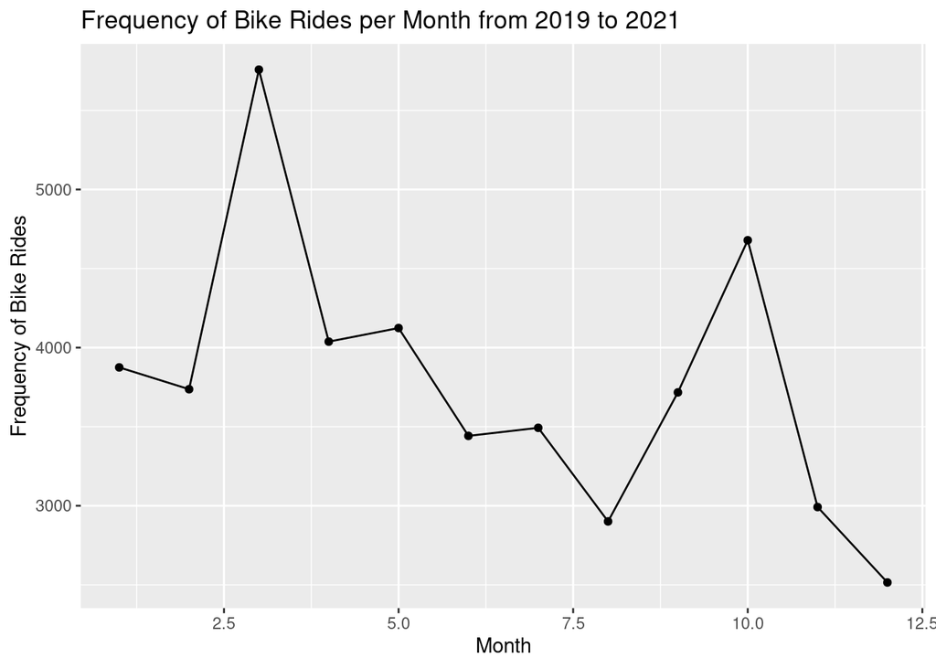

```r
# Frequency of trips by month from 2019 to 2021
amb |>
  group_by(Month) |>
  summarize(Frequency = n()) |>
  # Create plot of frequency of bike rides throughout 2019 to 2022
  ggplot(aes(x = Month, y = Frequency)) +
  geom_point() +
  geom_line() +
  labs(title = 'Frequency of Bike Rides per Month from 2019 to 2021',
       x = 'Month',
       y = 'Frequency of Bike Rides')
```

```r
# Get summary statistics
table(amb$Month)
```

```
##
##    1    2    3    4    5    6    7    8    9   10   11   12
## 3875 3737 5758 4038 4124 3442 3493 2901 3717 4679 2992 2515
```

As we can see, there is a spike during March and October and then a decrease during the Summer and Winter.

The next variable we want to analyze is the frequency of trips from 2019 to 2021. We expect to see a decline in bike trips in 2020 because it was during COVID-19.

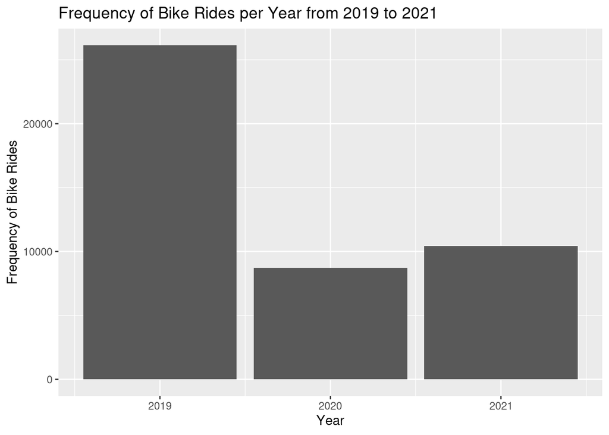

```r
# Frequency of trips by year from 2019 to 2021
amb |>
  group_by(Year) |>
  summarize(Frequency = n()) |>
  # Create plot of frequency of bike rides throughout 2019 to 2021
  ggplot(aes(x = Year, y = Frequency)) +
  geom_bar(stat = "identity") +
  labs(title = 'Frequency of Bike Rides per Year from 2019 to 2021',
       x = 'Year',
       y = 'Frequency of Bike Rides')
```

```r
# Get summary statistics
table(amb$Year)
```

```
##
##  2019  2020  2021
## 26132  8716 10423
```

We do see a drop in bike trips from 2019 to 2020. We can attribute this to the COVID-19 pandemic. We see a slight increase in bike rides from 2020 to 2021, which could attributed to the distribution of vaccines and the decrease in severe cases.

Again, we wanted to see the most frequent users of Austin Metrobikes. We expected the most frequent users to be students because they are more likely to commute on/off campus.

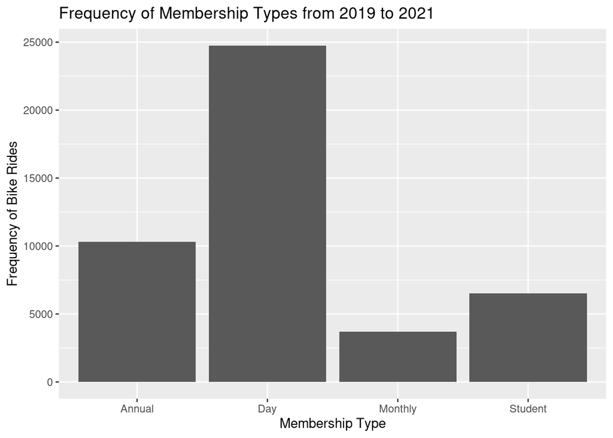

```r
# Create plot of frequency of membership types throughout 2019 to 2021
amb |>
  ggplot(aes(x = `Membership or Pass Type`)) +
  geom_bar() +
  labs(title = 'Frequency of Membership Types from 2019 to 2021',
       x = 'Membership Type',
       y = 'Frequency of Bike Rides')
```

```r
# Get summary statistics
table(amb$`Membership or Pass Type`)
```

```
##
##  Annual     Day Monthly Student
##   10306   24741    3709    6515
```

We actually see that the student membership type is one of the lowest frequent amount of passes used. Instead, it is the day pass, which makes sense because maybe people prefer to use other forms of transportation from getting on or off campus (ie. walking or taking the bus). If students do use bikes, they would probably want to use it for one time rather than multiple times.

Our next variable that we want to focus on is the time of day people are checking out the bikes. We expect most people to check out bikes in the morning and afternoon.

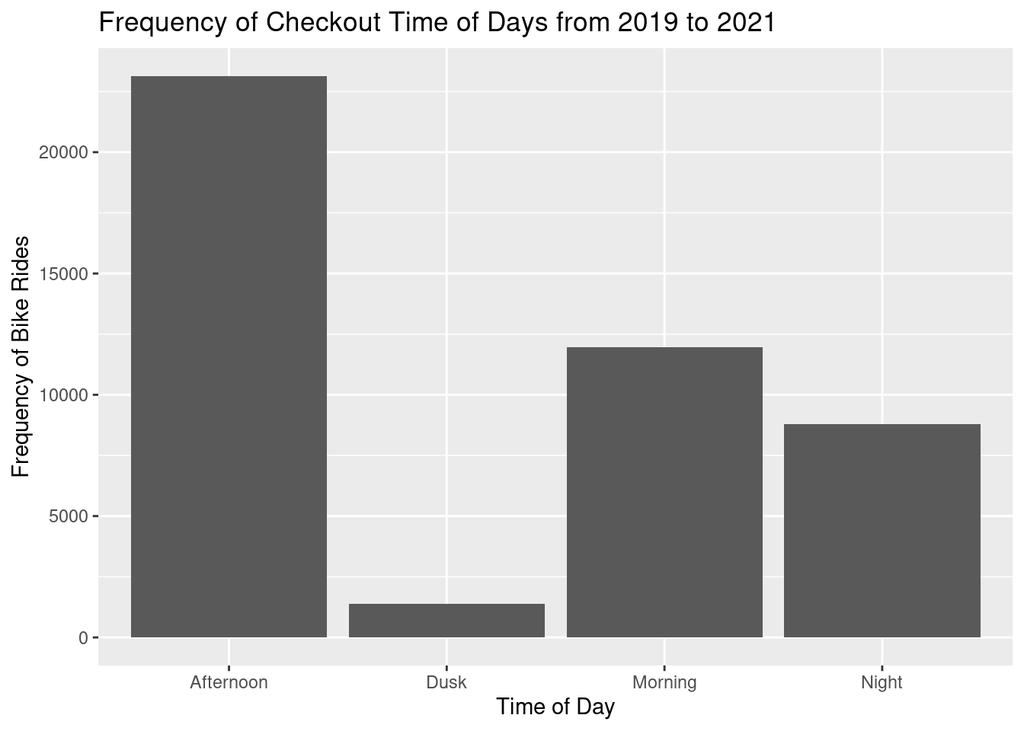

```r
# Create bar graph to see time of day of check outs
amb |>
  ggplot(aes(x = `Checkout TOD`)) +
  geom_bar() +
  labs(title = 'Frequency of Checkout Time of Days from 2019 to 2021',
       x = 'Time of Day',
       y = 'Frequency of Bike Rides')
```

```r
# Get summary statistics
table(amb$`Checkout TOD`)
```

```
##
## Afternoon      Dusk   Morning     Night
##     23132      1379     11972      8788
```

As expected, we see the most frequent bike rides occur in the afternoon or in the morning. We see a larger amount of the bike rides happening in the afternoon.

### b.) Bivariate Graphs

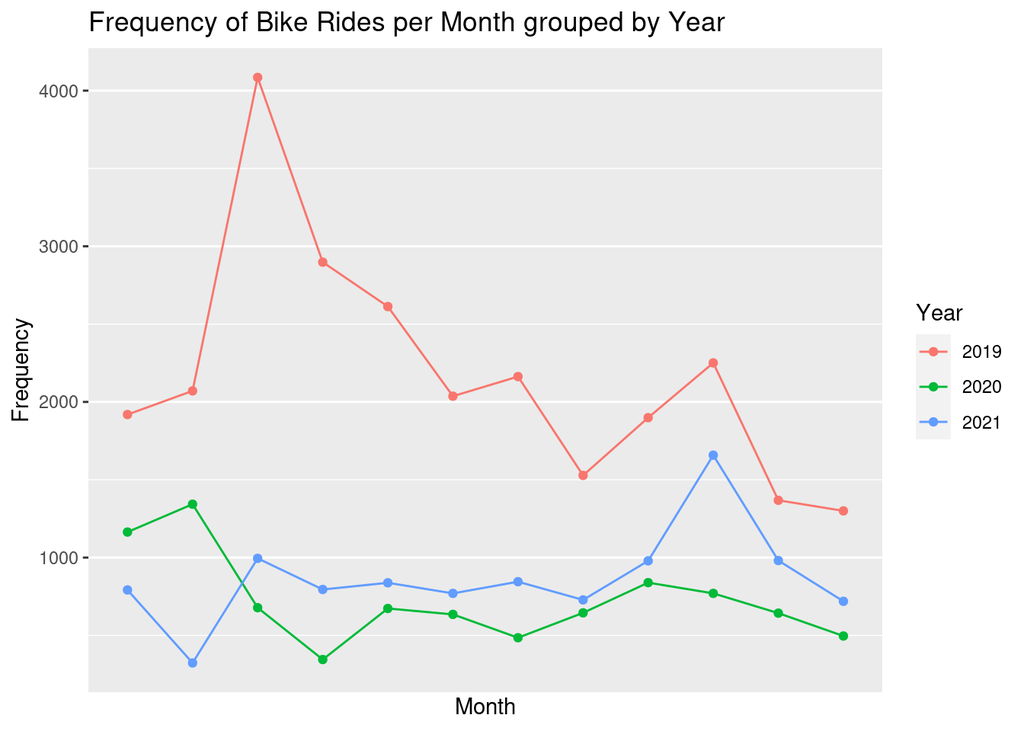

```r
# Frequency of Bike Rides per Month grouped by Year
amb |>
  group_by(Year, Month) |>
  summarize(Frequency = n(), .groups = "drop") |>
  # Create plot of frequency of bike rides
  ggplot(aes(x = Month, y = Frequency, color = factor(Year))) +
  geom_point() +
  geom_line() +
  labs(title = 'Frequency of Bike Rides per Month grouped by Year',
       x = 'Month',
       y = 'Frequency') +
  scale_x_discrete(labels = month.abb) +
  scale_color_discrete(name = 'Year')
```

```r
# Get summary statistics
amb |>
  group_by(Year, Month) |>
  summarize(Frequency = n()) |>
  arrange(desc(Frequency)) |>
  # Get top 10 rows
  head(10)
```

```
## # A tibble: 10 × 3
## # Groups:   Year [2]
##     Year Month Frequency
##    <dbl> <dbl>     <int>
##  1  2019     3      4085
##  2  2019     4      2898
##  3  2019     5      2613
##  4  2019    10      2251
##  5  2019     7      2163
##  6  2019     2      2071
##  7  2019     6      2037
##  8  2019     1      1919
##  9  2019     9      1899
## 10  2021    10      1658
```

We see that overall there are more bike rides in the year 2019 and the least in 2020. What is interesting is that in the year 2020, we see the sharp decrease in bike rides from February to March, which is around the time COVID-19 started to hit the United States.

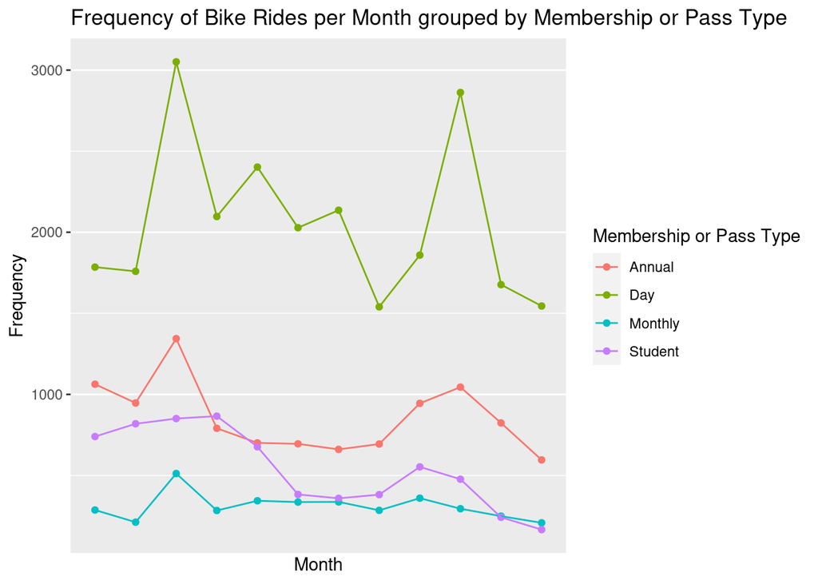

```r
# Frequency of Bike Rides per month grouped by membership type
amb |>
  group_by(`Membership or Pass Type`, Month) |>
  summarize(Frequency = n(), .groups = "drop") |>
  # Create plot of frequency of bike rides
  ggplot(aes(x = Month, y = Frequency, color = factor(`Membership or Pass Type`))) +
  geom_point() +
  geom_line() +
  labs(title = 'Frequency of Bike Rides per Month grouped by Membership or Pass Type',
       x = 'Month',
       y = 'Frequency') +
  scale_x_discrete(labels = month.abb) +
  scale_color_discrete(name = 'Membership or Pass Type')
```

```r
# Get summary statistics
amb |>
  group_by(`Membership or Pass Type`, Month) |>
  summarize(Frequency = n()) |>
  arrange(desc(Frequency)) |>
  # Get top 10 rows
  head(10)
```

```
## # A tibble: 10 × 3
## # Groups:   Membership or Pass Type [1]
##    `Membership or Pass Type` Month Frequency
##    <chr>                     <dbl>     <int>
##  1 Day                           3      3051
##  2 Day                          10      2862
##  3 Day                           5      2402
##  4 Day                           7      2136
##  5 Day                           4      2097
##  6 Day                           6      2028
##  7 Day                           9      1859
##  8 Day                           1      1785
##  9 Day                           2      1759
## 10 Day                          11      1677
```

Overall, we see that there are more day passes than the other three membership/pass types. The day pass also shows a positive trend in the Spring and Fall months and then a negative trend during the Summer and Winter months.

Let us install the ggmap package and also rstudioapi for map requirements.

```r
# Install packages
install.packages('ggmap')
install.packages('rstudioapi')
```

```r
# Load packages
library(ggmap)
library(ggplot2)
library(rstudioapi)

# Register google key
register_google()
```

Let’s create a map of the checkout locations now!

[figure not shown]

```r
# Load base map
checkout_map <- ggmap(get_googlemap(center = c(lon=-97.73769, lat=30.28624), zoom=13)) +
  # Add data points
  geom_point(data=amb_checkout, aes(x=Longitude, y=Latitude, color=Checkout_Count), size=2, alpha=.4) +
  labs(title='Places of Checkout Kiosks',
       x='Longitude',
       y='Latitude')

print(checkout_map)
```

```r
# Get summary statistics
amb_checkout |>
  arrange(desc(Checkout_Count)) |>
  # Get top 10 locations
  head(10) |>
  select(`Checkout Kiosk`,`Checkout_Count`)
```

```
## # A tibble: 10 × 3
## # Groups:   Kiosk ID [5]
##    `Kiosk ID` `Checkout Kiosk`                                    Checkout_Count
##         <dbl> <chr>                                                        <int>
##  1       3798 21st/Speedway @ PCL                                           2485
##  2       3798 21st & Speedway @PCL                                          2485
##  3       2575 Riverside @ S. Lamar                                          2009
##  4       2575 Riverside/South Lamar                                         2009
##  5       2707 Rainey/Cummings                                               1708
##  6       2707 Rainey St @ Cummings                                          1708
##  7       3377 MoPac Pedestrian Bridge @ Veterans Drive                      1353
##  8       3377 Veterans/Atlanta @ MoPac Ped Bridge                           1353
##  9       2566 Pfluger Bridge @ W 2nd Street                                 1299
## 10       2566 Electric Drive/Sandra Muraida Way @ Pfluger Ped Br…           1299
```

We see that there is a high amount of checkout locations on the UT Austin campus or around West campus. This is probably because there is a flux of students going to and from class from their apartment to campus. The most frequent amount of checkouts include the station by Jester West.

Let’s look at the return locations now!

[figure not shown]

```r
# Load base map
return_map <- ggmap(get_googlemap(center = c(lon=-97.73769, lat=30.28624), zoom=13)) +
  # Add data points
  geom_point(data=amb_return, aes(x=Longitude, y=Latitude, color=Return_Count), size=2, alpha=.4) +
  labs(title='Places of Return Kiosks',
       x='Longitude',
       y='Latitude')

print(return_map)
```

```r
# Get summary statistics
amb_return |>
  arrange(desc(Return_Count)) |>
  # Get top 10 locations
  head(10) |>
  select(`Return Kiosk`,`Return_Count`)
```

```
## # A tibble: 10 × 3
## # Groups:   Kiosk ID [5]
##    `Kiosk ID` `Return Kiosk`                                        Return_Count
##         <dbl> <chr>                                                        <int>
##  1       2575 Riverside/South Lamar                                         1777
##  2       2575 Riverside @ S. Lamar                                          1777
##  3       2707 Rainey St @ Cummings                                          1616
##  4       2707 Rainey/Cummings                                               1616
##  5       3798 21st/Speedway @ PCL                                           1602
##  6       3798 21st & Speedway @PCL                                          1602
##  7       3377 MoPac Pedestrian Bridge @ Veterans Drive                      1374
##  8       3377 Veterans/Atlanta @ MoPac Ped Bridge                           1374
##  9       2566 Pfluger Bridge @ W 2nd Street                                 1292
## 10       2566 Electric Drive/Sandra Muraida Way @ Pfluger Ped Brid…         1292
```

We see there is still a lot of bikes being returned at the Speedway/21st stop and around West campus as well. However, looking at the summary statistics, we see the most frequent bike returns happen in Riverside and South Lamar, which is 3.2 miles away from the most frequent checkout location.

## 4. Discussion

If we were going to share our findings with the City of Austin, the main takeaway from our explanatory data analysis would be whether or not MetroBike resources are being allocated to groups of people that use them most and how resources should be used.

Our first research question was whether or not there is an abundance of bikes in certain locations that they are being checked out or dropped off at. After performing analysis on the check in and checkout locations of bikes, it was found that there is a concentration of bikes being checked out near or on the UT campus. It was also found that a majority of available bike check-out locations are near downtown Austin, which is not a common checkout source for UT students knowing that a majority live near campus, like west campus. This means that the city of Austin has to redistribute bikes from kiosks with more return locations (like Riverside and S Lamar) and return them back to more frequent checked out locations (21st and Speedway). This could also mean that the city of Austin could provide more bike stations around UT and west campus because more checkouts happen there. The locations that bikes were commonly checked in or out were visualized by using another dataset that proved the coordinates fo each kiosk location. From the information provided in this dataset, the ‘ggmap’ and ‘rstudioapi’ packages were used to create a map showing the locations of bike kiosks in Austin. Using the ‘rstudioapi’ package, we were able to plot the longitude and latitude of each kiosks on a Google map and visualized the frequency of kiosks using ‘alphakey’ function.

Our second research question was how Austin MetroBikes was affected by the COVID-19 pandemic and whether or not they showed recovery from 2020. After conducting an analysis on this question, it was found that there was a drastic decrease in MetroBike usage in 2020 when compared to 2019. It was also discovered that there was an increase in MetroBike usage in 2021, when COVID-19 cases were slowly dissipating and treatments/vaccines were accessible. This means that the MetroBike system was negatively affected by the COVID-19 pandemic, but are slowly regaining users. The comparison of the years 2019, 2020, and 2021 were visualized using a bar graph with the years on the x-axis and number of bike rides of in the y-axis.

Lastly, our third research question focused on the types of passes that were being utilized for each trip. We expected students to use MetroBikes more frequently and for them to be checked out during the morning or afternoon time because students are travelling to/from classes. It was discovered that more frequent bike rides happening during the day time (morning and afternoon). This was visualized by graphing the frequency of membership types and then also graphing the frequency of bikes checked out during dusk, morning, afternoon, and night time.

The data from these three research questions mostly matched what we expected prior to performing our analysis. We expected more bike checkout locations to be near or on UT campus and for bike rides to show a decrease in 2020 due to the pandemic. We also expected most bike rides to happen during the day. One thing that we found surprising from our analysis was that there was an abundance of bike checkout kiosks near downtown Austin in comparison to near or on UT campus. Another thing we found suprising from out analysis was that students were not utilizing the student membership passes as frequently as day passes.Something that we are curious about is how checkout MetroBike kiosk locations were determined. We wonder if they were determined by the population in certain locations or by demographics such as age and occupation.

One inconsistency that appeared when coding for categories was that there were kiosk location names that were the same but had different names in the dataset. For example, some kiosk locations were named under 3rd/Nueces and some were names 3rd and Nueces. These are the same kiosk location but named differently as some used a slash symbol and some used the word: and. This discrepancy remains consistent throughout the dataset; however, it did not impact our findings as the data could still be interpreted regardless of the grammatical difference.

## 5. Reflection, acknowledgements, and references

The aspect of the project that we found to be the most challenging was narrowing the dataset enough to where it would upload properly into R Studio. This challenge caused us to adjust our research questions slightly in order to accommodate for the changes made in the dataset. For example, we wanted to analyze the MetroBike usage from 2019-to present time to determine a trend of growth or decrease from pre-pandemic, during the pandemic, and post-pandemic into present time. However, because the dataset containing years 2019-2024 was too large to upload into R Studio, we decided to narrow the years down to 2019, 2020, and 2021 to analyze the immediate effect of COVID-19 on bike usage and its after effects.

One thing that we learned from the process itself was not to procrastinate the project until the due date is approaching. This project required a lot of work out outside of class and was not something that can easily be done last minute. If we were to repeat this analysis, we would have started much earlier so that we could work gradually to allow us to balance our other classes and responsibilities while providing a thorough analysis of our data.

As for acknowledgements, we would like to extend a thank you to Professor Guyot and the TAs for providing resources for us to complete this project while gaining insightful knowledge on the process of data analysis. This project was a team collaboration with Hannah Sepnio and Aleiza Belista. Hannah Sepnio contributed to making the univariate graphs for the categorical variables: pass/membership type and kiosk location. Hannah also made the bivariate graphs using maps to represent membership/pass prevalence and kiosk locations as well as the introduction, methods, and results section of the EDA Report. Aleiza Belista contributed to making the univariate graphs for the numerical variables of month and year and the bivariate graphs that show the relationship between bike rides/month/year and the graph for pass or membership/month/year. Aleiza also contributed to the title and introduction, discussion, as well as the reflection/acknowledgment/and references sections of the EDA Report.

The links of the datasets and background article we used are provided below:

Austin MetroBike Trips Dataset: https://data.austintexas.gov/Transportation-and-Mobility/Austin-MetroBike-Trips/tyfh-5r8s/about_data

Austin MetroBike Locations Dataset: https://data.austintexas.gov/Transportation-and-Mobility/Austin-MetroBike-Kiosk-Locations/qd73-bsdg/data

Background Knowledge Article: https://www.austinmonitor.com/stories/2023/10/metrobike-wins-11-3-million-federal-grant-to-fund-transition-to-electric-bicycles/

## 6. Modeling and Cross-Validation

### a.) Predicting Checkout Count

```r
amb_checkout <- distinct(amb_checkout, `Kiosk ID`, .keep_all = TRUE)
amb_checkout <- as.data.frame(amb_checkout)
```

```r
# kNN predicting checkout_count with latitude and longitude

fit_knnreg <- knnreg(Checkout_Count ~ Latitude + Longitude,
                     data = amb_checkout,
                     k = 5) # Number of Neighbors

# Predict with RMSE
sqrt(mean((amb_checkout$Checkout_Count - predict(fit_knnreg, amb_checkout))^2))
```

```
## [1] 326.9053
```

```r
# Create train and test data

# Sample 70% of the rows for training data
train_data <- sample_frac(amb_checkout, 0.7)

# Use the remaining rows for testing data
test_data <- anti_join(amb_checkout, train_data, by = "Kiosk ID")

# Check if the sum of rows in train_data and test_data equals the total rows in amb_checkout
nrow(train_data) + nrow(test_data) == nrow(amb_checkout)
```

```
## [1] TRUE
```

```r
# Set up cross validation
k = 5 # 5 folds

# To have the same random sample, use set.seed
set.seed(322)

# Randomly order rows in the dataset
data <- amb_checkout[sample(nrow(amb_checkout)), ]

# Create k folds from the dataset
folds <- cut(seq(1:nrow(data)), breaks = k, labels = FALSE)
```

```r
# Initialize a vector to keep track of the performance for each k-fold
perf_k <- NULL

# Use a for-loop to get performance for each k-fold
for(i in 1:k){
  # Split data into train and test data
  train_not_i <- data[folds != i, ] # train data = all observations except in fold i
  test_i <- data[folds == i, ]  # test data = observations in fold i

  # Train model on train data (all but fold i)
  # ONLY CHANGE: what model we consider
  train_model <- knnreg(Checkout_Count ~ Latitude + Longitude,
                     data = train_not_i,
                     k = 5)

  # Performance listed for each test data = fold i
  perf_k[i] <- sqrt(mean((
    test_i$Checkout_Count - predict(train_model, newdata = test_i))^2,
    na.rm = TRUE))
}

# Performance for each fold
perf_k
```

```
## [1] 595.3323 347.5391 238.5800 365.5186 452.9096
```

```r
# Check performance
mean(perf_k)
```

```
## [1] 399.9759
```

```r
sd(perf_k)
```

```
## [1] 133.1838
```

### b.) Predicing Return Count

```r
amb_return <- distinct(amb_return, `Kiosk ID`, .keep_all = TRUE)
amb_return <- as.data.frame(amb_return)
```

```r
# kNN predicting return_count with latitude and longitude

fit_knnreg <- knnreg(Return_Count ~ Latitude + Longitude,
                     data = amb_return,
                     k = 5) # Number of Neighbors

# Predict with RMSE
sqrt(mean((amb_return$Return_Count - predict(fit_knnreg, amb_return))^2))
```

```
## [1] 286.3571
```

```r
# Create train and test data

# Sample 70% of the rows for training data
train_data <- sample_frac(amb_return, 0.7)

# Use the remaining rows for testing data
test_data <- anti_join(amb_return, train_data, by = "Kiosk ID")

# Check if the sum of rows in train_data and test_data equals the total rows in amb_checkout
nrow(train_data) + nrow(test_data) == nrow(amb_return)
```

```
## [1] TRUE
```

```r
# Set up cross validation
k = 5 # 5 folds

# To have the same random sample, use set.seed
set.seed(322)

# Randomly order rows in the dataset
data <- amb_return[sample(nrow(amb_return)), ]

# Create k folds from the dataset
folds <- cut(seq(1:nrow(data)), breaks = k, labels = FALSE)
```

```r
# Initialize a vector to keep track of the performance for each k-fold
perf_k <- NULL

# Use a for-loop to get performance for each k-fold
for(i in 1:k){
  # Split data into train and test data
  train_not_i <- data[folds != i, ] # train data = all observations except in fold i
  test_i <- data[folds == i, ]  # test data = observations in fold i

  # Train model on train data (all but fold i)
  # ONLY CHANGE: what model we consider
  train_model <- knnreg(Return_Count ~ Latitude + Longitude,
                     data = train_not_i,
                     k = 5)

  # Performance listed for each test data = fold i
  perf_k[i] <- sqrt(mean((
    test_i$Return_Count - predict(train_model, newdata = test_i))^2,
    na.rm = TRUE))
}

# Performance for each fold
perf_k
```

```
## [1] 531.2843 385.1075 307.8119 263.9979 321.3268
```

```r
# Check performance
mean(perf_k)
```

```
## [1] 361.9057
```

```r
sd(perf_k)
```

```
## [1] 104.1467
```

```r
dim(amb)
```

```
## [1] 45271    11
```

```r
dim(amb_checkout)
```

```
## [1] 78  5
```

```r
dim(amb_return)
```

```
## [1] 78  5
```